# Mixed Models / Hierarchical Models

Benedikt Ehinger

2026-09-11

# Slides & my Presentation style

Click this link to add notes to the slides

this adds `?showNotes=true` to the file

You can download the pdf or print them yourself:

click this link for pdf printable (use google chrome)

click this link for pdf printable + notes

HTML is best viewed in chrome

# Why repeated measures?

## Repeated measures

[figure not shown]

It looks like there is no difference between groups?

But what if we have data from within the same subjects?

## Repeated measures

[figure not shown]

## Removing individual differences

[figure not shown]

Between-Subject variability can be removed by repeated measures. This can result in higher power!

## Accounting for repeated measures?

[figure not shown]

$n_S=5$ subjects

## Sampling distributions

[figure not shown]

## Multiple trials per subject

with

[figure not shown]

$n_T =15$ trials

## Sampling distributions

[figure not shown]

This sampling distribution reflects these exact 5 subjects. But does not generalize!

## Sampling distributions

[figure not shown]

(pink for aggregate, purple for disaggregate). There is a strong allure to choose the smaller one, easier to get significant results!

$$n_{subject}(aggregate) = df+1 = 5$$
$$n_{subject}(pseudoreplication) = df+1= 15*5 = 75$$

**Never analyze repeated measures data without taking repeated measures into account** (Disaggregation, Pseudoreplication).

## Always necessary to aggregate?

[figure not shown]

$$\sigma_{within} >> \sigma_{between}$$

Subjects are very **similar**

**Not so necessary to aggregate first**

A single parameter summarizes subject-means well

[figure not shown]

$$\sigma_{within} << \sigma_{between}$$

Subjects are very **different**

**Totally necessary to aggregate first**

$n_{subject}$ parameters summarizes subject-means well

## Should we trust all subjects equally?

[figure not shown]

**Question:** Estimate the mean of the population

## Should we trust all subjects equally?

[figure not shown]

We should take into account **sample-size** into our estimate of the population mean

We should trust those subjects more, where we most sure about their central tendency

## Summary

- **Why repeated measures**
  - More power to find effects that exist!
- **Don’t forget about repeated measures!**
  - Else your type I error will be very high
- **Should we trust all subjects equally?**
  - No, we should punish for small within-subject sample-size and punish high variance

# An example to guide you through the steps

## The example

```
Minimizing 2    Time: 0:00:00 (95.75 ms/it)
   objective: 1151.6265401473452


Minimizing 131    Time: 0:00:00 ( 2.80 ms/it)
```

|  | Est. | SE | z | p | σ_subject |
| --- | --- | --- | --- | --- | --- |
| (Intercept) | 3.7173 | 1.0037 | 3.70 | 0.0002 | 3.0142 |
| contrast | 0.1109 | 0.0322 | 3.45 | 0.0006 | 0.1300 |
| Residual | 6.6519 |  |  |  |  |

Experiment: Contrast vs. Density Estimation

[figure not shown]

## The data

[figure not shown]

## One model for all subjects

[figure not shown]

$$\hat{y} = \beta_0 + \beta_1 * contrast$$

## One model for each subject

[figure not shown]

$$\hat{y_j} = \beta_{0,j} + \beta_{1,j} * contrast$$

## Excursion: two-stage statistics

[figure not shown]

# The LMM

## One solution

[figure not shown]

**Linear Mixed Model** aka **Hierarchical Model** aka **Multilevel Model**

We estimate the population distribution directly. Subject-means with high uncertainty due to different trial numbers are less influential for the model fit

## A compromise

[figure not shown]

Small second level variance (limit $0$)

Parameters/DF assumed to be n-trials

[figure not shown]

Large second level variance (limit $\infty$)

Parameters/DF assumed to be subjects

[figure not shown]

shrinkageometer

## Formal definition of the linear mixed model

[figure not shown]

## A word of warning

> Encouraging psycholinguists to use linear mixed-effects models ‘was like giving shotguns to toddlers’ (Barr)

> Because mixed models are more complex and more flexible than the general linear model, the potential for confusion and errors is higher (Hamer)

Many ongoing riddles:

[Book: Richly Parameterized Linear Models](http://www.biostat.umn.edu/~hodges/RPLMBook/RPLMBookpage.htm)

- Chp. 9: Puzzles from Analyzing Real Data sets
- Chp.10: A Random Effect Competing with a Fixed Effect
- Chp.12: Competition between Random Effects
- Chp.14: Mysterious, Inconvenient or Wrong Results from Real Datasets

## The mixed model in Julia

$\hat{y} = \beta_0 + \beta_1 * contrast + u_{0,j} + u_{1,j} * contrast$

$\hat{y}_j = \beta X_j + b_jZ$

Fitting this in Julia using the package **MixedModels.jl**

`@formula(estim_error ~ 1 + contrast + (1 + contrast | subject))`

Note: In R::LME4 use `||` for uncorrelated random effects: `estim_error ~ 1 + contrast + (1 + contrast || subject))`

## Mixed models in Julia

```
Linear mixed model fit by maximum likelihood
 estim_error ~ 1 + contrast + (1 + contrast | subject)
   logLik   -2 logLik     AIC       AICc        BIC
 -1110.0822  2220.1644  2232.1644  2232.4286  2254.8674

Variance components:
            Column    Variance Std.Dev.   Corr.
subject  (Intercept)   9.085415 3.014202
         contrast      0.016902 0.130008 -0.46
Residual              44.248367 6.651945
 Number of obs: 325; levels of grouping factors: 20

  Fixed-effects parameters:
─────────────────────────────────────────────────
                Coef.  Std. Error     z  Pr(>|z|)
─────────────────────────────────────────────────
(Intercept)  3.71733    1.0037     3.70    0.0002
contrast     0.110879   0.0321549  3.45    0.0006
─────────────────────────────────────────────────
```

gray: one model, color: individual model, black: mixed model

[figure not shown]

# Methods, Stats, etc. around LMMs

## REML VS ML

### Intuition:

When estimating the variance parameter using maximum likelihood (**ML**) $\sigma$ is biased because $\mu$ is not known at the same time

### Solution:

Fit all fixed effects $\mu$, then refit the variance parameters on the residing estimates.

This is called restricted maximum likelihood (**REML**). If $n$ is large, no difference between **ML** and **REML** exist. If $n$ (i.e. $n_{subjects}$) is small **REML** gives better predictive results.

If you do model comparison and fixed effects differ (usual case) you have to use **ML**. If ML-models were simplified using LRT, best practice to report the REML model at the end.

## Bootstrapping

- resample from the data with replacement (or parametrically from $H_0$-Model) $N$ times
- calculate statistic of interest
- observe spread of statistic

[figure not shown]

## Model-Comparisons aka p-values

Unresolved problem!

Read (three links): - [how to get p values](https://rdrr.io/cran/lme4/man/pvalues.html) - [problems with stepwise regression](http://www.stata.com/support/faqs/statistics/stepwise-regression-problems/), - [different ways to get p-values](http://glmm.wikidot.com/faq)

One way (good and common, but not the best*): Model comparison for fixed effects:

**Be sure to keep random structure equal**

```julia
mres0 = lmm(@formula(estim_error ~ 1 + (1+contrast | subject)), d)
mres1 = lmm(@formula(estim_error ~ 1 + contrast + (1+contrast | subject)), d)
lrtest(mres0,mres1)
```

```
Likelihood-ratio test: 2 models fitted on 325 observations
────────────────────────────────────────────────────────
     DOF  ΔDOF      LogLik   Deviance   Chisq  p(>Chisq)
────────────────────────────────────────────────────────
[1]    5        -1114.6313  2229.2626
[2]    6     1  -1110.0822  2220.1644  9.0982     0.0026
────────────────────────────────────────────────────────
```

## Wald confidence intervals

Simpler approach: Wald-based confidence intervals

```julia
mres1 |> DisplayAs.Text
```

```
Linear mixed model fit by maximum likelihood
 estim_error ~ 1 + contrast + (1 + contrast | subject)
   logLik   -2 logLik     AIC       AICc        BIC
 -1110.0822  2220.1644  2232.1644  2232.4286  2254.8674

Variance components:
            Column    Variance Std.Dev.   Corr.
subject  (Intercept)   9.085415 3.014202
         contrast      0.016902 0.130008 -0.46
Residual              44.248367 6.651945
 Number of obs: 325; levels of grouping factors: 20

  Fixed-effects parameters:
─────────────────────────────────────────────────
                Coef.  Std. Error     z  Pr(>|z|)
─────────────────────────────────────────────────
(Intercept)  3.71733    1.0037     3.70    0.0002
contrast     0.110879   0.0321549  3.45    0.0006
─────────────────────────────────────────────────
```

```julia
confint(mres1)
```

```
DictTable with 2 columns and 2 rows:
 coef          lower      upper
 ────────────┬────────────────────
 (Intercept) │ 1.75013    5.68454
 contrast    │ 0.0478563  0.173901
```

Wald confidence intervals are **approximate** but computationally efficient.

**For small samples please consider other methods!**

## Degrees of Freedom

### Why wald is approximate?

Some packages (e.g. `R::lme4`) refuse to provide p-values, because the “degree of freedom” are not defineable.

Are they $n_{subject}$? Is it $n_{total-trials}$? Somewhere in between?

Each method to make a decision (e.g. Wald’s, Bootstrap, MCMC, Profiling, Permutation) makes some kind of assumption on this.

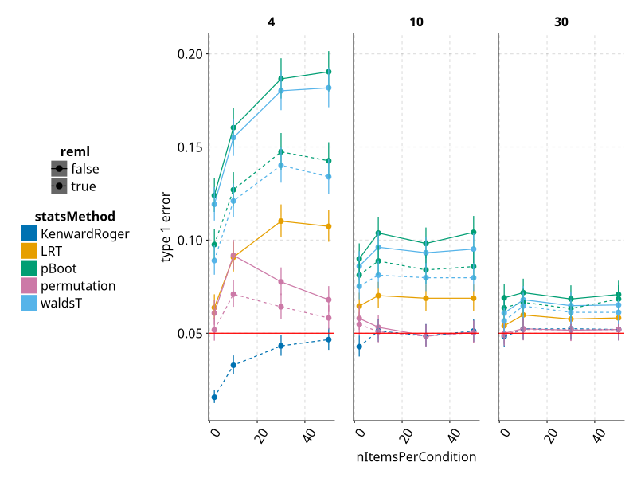

## Kenward Roger / Satterthwaite

```julia
using MixedModelsSmallSample
mres1_reml = lmm(@formula(estim_error ~ 1 + contrast + (1+contrast | subject)), d;REML=true)
kr = small_sample_adjust(mres1_reml,KenwardRoger())
sw = small_sample_adjust(mres1_reml,Satterthwaite())

coeftable(mres1_reml)
```

|  | Coef. | Std. Error | z | Pr(>\|z\|) |
| --- | --- | --- | --- | --- |
| (Intercept) | 3.72909 | 1.03682 | 3.60 | 0.0003 |
| contrast | 0.110658 | 0.0331202 | 3.34 | 0.0008 |

```julia
coeftable(kr)
```

|  | Coef. | Std. Error | DenDF | t | Pr(>\|t\|) |
| --- | --- | --- | --- | --- | --- |
| (Intercept) | 3.72909 | 1.04419 | 15.508 | 3.57 | 0.0027 |
| contrast | 0.110658 | 0.0331925 | 17.9404 | 3.33 | 0.0037 |

```julia
coeftable(sw)
```

|  | Coef. | Std. Error | DenDF | t | Pr(>\|t\|) |
| --- | --- | --- | --- | --- | --- |
| (Intercept) | 3.72909 | 1.03682 | 15.508 | 3.60 | 0.0025 |
| contrast | 0.110658 | 0.0331202 | 17.9404 | 3.34 | 0.0036 |

# Assumption checking

## Checking assumptions level I

|  | Est. | SE | z | p | σ_subject |
| --- | --- | --- | --- | --- | --- |
| (Intercept) | 3.7173 | 1.0037 | 3.70 | 0.0002 | 3.0142 |
| contrast | 0.1109 | 0.0322 | 3.45 | 0.0006 | 0.1300 |
| Residual | 6.6519 |  |  |  |  |

[figure not shown]

No strong non-linearity visible in residuals

[figure not shown]

QQ plot indicates normality of residuals

## Checking assumptions level II

In addition: test whether normality for random-variable is true:

[figure not shown]

QQ plot indicates normality of random effects, potentially some outliers on hte left side

# Shrinkage

## Shrinkage

[figure not shown]

The individual estimates with high variance / far off the population are *shrinked* inwards

## Shrinkage-plot

[figure not shown]

gray: one model, color: individual model, black: mixed model (with shrinkage)

## Shrinkage over multiple parameters

[figure not shown]

**Simulated data**: Subjects with faster reaction time (intercept) show larger effects for difficulty (slope)

In reverse: If I know somebody is generally slow, he should also have a smaller slope!

## The multivariate normal I

[interactive chart not shown]

## The multivariate normal II

[figure not shown]

$\rho = 0$, knowing one dimension does not tell you about the other

$$\sum = \left[ {\begin{array}{*{20}{c}}
1&0 \\
0 &1
\end{array}} \right]$$

[figure not shown]

$\rho = 0.6$, knowing one dimension tells you something about the other

$$\sum = \left[ {\begin{array}{*{20}{c}}
1&0.6 \\
0.6 &1
\end{array}} \right]$$

## Back to mixed models

[figure not shown]

$$\sum = \left[ {\begin{array}{*{20}{c}}
1&\rho \\
\rho &1
\end{array}} \right]$$

[figure not shown]

Similar to `degree of freedom`, if we have a true underlying correlation between random slopes, we ought to model it - as the datapoints are not as independent as we are hoping for (correlation = 0 assumes independence).

## Naming is a bit messy

#### Random/Fixed Coefficients

- **Random intercept** `(1 | subject)`: Different offset for each subject
- **Random slope** `(predictor | subject)`: Different predictor-slope for each subject
- **Random correlation** `(1 + predictor | subject)` or `(X + Y | subject)`: Knowing about X tells you something about Y
- **Fixed coefficient** exactly the same for all subjects

#### Random/Fixed Variables

- **Random variable** Instance $\in$ population, e.g. subjects, images, words
- **Fixed variable** limited number of possible values or no generalization to population needed, e.g. 3 different experimental conditions

*Random effect* also used for either *random coefficient* or *random variable*

*Fixed effect* usually refers to the estimator of the population mean

source and another 5 [different definitions here](http://andrewgelman.com/2005/01/25/why_i_dont_use/)

## When to include what

### Some guidance:

- Predictor is a subset of a population?

  => random/grouping variable e.g. subjects, images, words
- Predictor is within subject/grouping?

  => random coefficients
- Predictor is between subject/grouping or aggregated?

  => only fixed coefficient

## A quiz on when something is what

very often you will need to decide whether something belongs to the fixed effects, to the random effects, or both.

# Convergence & Singularity

## A more complex model

```julia
d.contrastSquare = d.contrast .^ 2

m_complex = lmm(@formula(estim_error ~ 1 + contrast + contrastSquare + (1 + contrast + contrastSquare | subject)), d)
m_complex |> DisplayAs.Text
```

[output not shown]

```
Linear mixed model fit by maximum likelihood
 estim_error ~ 1 + contrast + contrastSquare + (1 + contrast + contrastSquare | subject)
   logLik   -2 logLik     AIC       AICc        BIC
 -1109.8707  2219.7415  2239.7415  2240.4421  2277.5797

Variance components:
             Column       Variance   Std.Dev.    Corr.
subject  (Intercept)     33.70396553 5.80551165
         contrast         0.04929162 0.22201717 -0.83
         contrastSquare   0.00000083 0.00091138 +0.99 -0.91
Residual                 42.86672821 6.54726876
 Number of obs: 325; levels of grouping factors: 20

  Fixed-effects parameters:
────────────────────────────────────────────────────────
                      Coef.   Std. Error     z  Pr(>|z|)
────────────────────────────────────────────────────────
(Intercept)     5.08396      1.70072      2.99    0.0028
contrast        0.0280692    0.0716026    0.39    0.6950
contrastSquare  0.000819554  0.000537696  1.52    0.1275
────────────────────────────────────────────────────────
```

## Common warnings signs

- R: Model failed to converge: degenerate Hessian with negative eigenvalues
- Julia: `PosDefException`
- Optimizers needs maaaany iterations

## Convergence vs. Singularity problems

### Convergences

- Real convergence problems are rare in R::lme4, and extremely rare in MixedModels.jl
- Typically the objective function is extremely flat and the optimizer struggles => change optimizer, change data (outliers?), missspecifications
- Center predictors (remove mean) and scale (divide by SD of independent variable)

### Singularity

**Most common issue** is singular fits

#### How to Spot?

- -1/+1/0 in variance estimation
- `rePCA`
- likelihood ratio tests

#### Why?

You don’t have enough data to estimate the random effects structure

#### How to fix?

Different opinions: 1. “Keep it maximal” - nothing to do, just use as is 2. “Simplify” - simplify until non-singular

## The ideal case

$$\sum = \left[ {\begin{array}{*{20}{c}}
1&{{\rho_{ab}}}&{{\rho_{ac}}}&{{\rho_{ad}}}\\
{{\rho_{ab}}}&1&{{\rho_{bc}}}&{{\rho_{bd}}}\\
{{\rho_{ac}}}&{{\rho_{bc}}}&1&{{\rho_{cd}}}\\
{{\rho_{ad}}}&{{\rho_{bd}}}&{{\rho_{cd}}}&1
\end{array}} \right]$$

`@formula(y ~ 1 + A + B + C + (1 + A + B + C | group))`

If you have enough data, try to estimate all correlations.

## The simplest structure

$$\Sigma = \left[ {\begin{array}{*{20}{c}}
1&0&0&0\\
0&1&0&0\\
0&0&1&0\\
0&0&0&1
\end{array}} \right]$$

`@formula(y ~ 1 + X1 + X2 + X3 + zerocorr(1 + X1 + X2 + X3 | group))`

R::LME4 `formula y ~ 1 + X1 + X2 + X3 + (1 + X1 + X2 + X3 || group)`

note the `||` instead of `|`

$$\Sigma = \left[ {\begin{array}{*{20}{c}}
1&{{\rho _a}}&{{\rho _a}}&{{\rho _a}}\\
{{\rho _a}}&1&{{\rho _a}}&{{\rho _a}}\\
{{\rho _a}}&{{\rho _a}}&1&{{\rho _a}}\\
{{\rho _a}}&{{\rho _a}}&{{\rho _a}}&1
\end{array}} \right]$$

Compound symmetry $\simeq$ Repeated measures ANOVA

`@formula(y ~ 1 + X1 + (1 | group) + (1 | group:X1))`

## Which one to choose?

- 1: You can estimate the full (enough data or put a LKJ-prior if you are Bayesian)
- 2: Prior assumption on shape and you don’t have to change it (non-contingent on data)
- 3: Simplify in a data-driven way

Ongoing debate [“Keep it maximal”, Barr et al. 2013](https://www.ncbi.nlm.nih.gov/pmc/articles/PMC3881361/) vs. [“Parsimonious mixed models”, Bates et al. 2015](https://arxiv.org/abs/1506.04967) and “Balancing Type I error and power in linear mixed models”, Matuschek et al. 2017

Barr promotes full models. Bates/Matuschek promotes a step wise reduction if effects do not significantly explain variance

## A clarification to simplification

Often people simplify like this:

```
y ~ 1 + X * Y + (1 + X * Y | group)

y ~ 1 + X * Y + zerocorr(1 + X * Y | group)

y ~ 1 + X * Y + zerocorr(1 + X + Y | group)

y ~ 1 + X * Y + zerocorr(1 + X | group)

y ~ 1 + X * Y + (1 | group)
```

But if your hypothesis is on the interaction of `X&Y`, (following Matuschek) you should rather

```
y ~ 1 + X * Y + (1 + X * Y | group)

y ~ 1 + X * Y + zerocorr(1 + X * Y | group)

y ~ 1 + X * Y + zerocorr(1 + X + X&Y | group)

y ~ 1 + X * Y + zerocorr(1 + X&Y| group)

y ~ 1 + X * Y + (0 + X&Y | group)
```

i.e. keep the random slopes for the effect you are most interested in the longest.

## Words of warnings

> A common misconception is that crossing subjects and items in the intercept term of LMEMs is sufficient for meeting the assumption of conditional independence, and that including random slopes is strictly unnecessary […]. Indeed, some researchers have already warned against using random-intercepts-only models when random slope variation is present (e.g., Baayen, 2008; Jaeger, 2011a; Roland, 2009; Schielzeth & Forstmeier, 2009)

*Barr et. al. 2013*

[Read a more detailed discussion on my blog](https://benediktehinger.de/blog/science/lmm-type-1-error-for-1condition1subject/)

# Item effects

## Multiple random variables

[figure not shown]

## Model summary

```
Linear mixed model fit by maximum likelihood
 y ~ 1 + condition + (1 + condition | subject)
   logLik   -2 logLik     AIC       AICc        BIC
 -4286.7265  8573.4529  8585.4529  8585.5470  8614.2673

Variance components:
            Column    Variance   Std.Dev.   Corr.
subject  (Intercept)   28.217447  5.312010
         condition      0.849759  0.921824 -1.00
Residual              785.775695 28.031691
 Number of obs: 900; levels of grouping factors: 30

  Fixed-effects parameters:
──────────────────────────────────────────────────
                Coef.  Std. Error      z  Pr(>|z|)
──────────────────────────────────────────────────
(Intercept)  -1.84133     1.63913  -1.12    0.2613
condition    -4.59955     1.87634  -2.45    0.0142
──────────────────────────────────────────────────
```

What a nice effect! Write paper and end of story?

## But very high stimulus variance!

[figure not shown]

## But very high stimulus variance!

[figure not shown]

## But very high stimulus variance

[figure not shown]

High unmodelled variance can lead to sporadic effects.

## Model with stimulus random effect

```
Linear mixed model fit by maximum likelihood
 y ~ 1 + condition + (1 + condition | subject) + (1 + condition | stimulus)
   logLik   -2 logLik     AIC       AICc        BIC
 -2494.3762  4988.7523  5006.7523  5006.9546  5049.9739

Variance components:
            Column    Variance Std.Dev.   Corr.
subject  (Intercept)   71.09469  8.43177
         condition     51.71847  7.19156 -0.55
stimulus (Intercept)  603.84803 24.57332
         condition     25.64481  5.06407 +1.00
Residual                8.62000  2.93598
 Number of obs: 900; levels of grouping factors: 30, 30

  Fixed-effects parameters:
──────────────────────────────────────────────────
                Coef.  Std. Error      z  Pr(>|z|)
──────────────────────────────────────────────────
(Intercept)  -1.84133     6.53035  -0.28    0.7780
condition    -4.59955    10.0285   -0.46    0.6465
──────────────────────────────────────────────────
```

Often it is necessary to add multiple random effects! Examples are: subjects, stimuli (images, words, etc)

`@formula(y ~ 1 + condA + (1 + condA | subject) + (1 | stimulus))`

## What to generalize over?

### Why do we add subject random effects?

We want to generalize over subjects

### Why should we add item random effects?

We want to generalize over items!

If we leave one of these two, we will ($\approx$) make statistical inferences on the sample at hand, without much generalization.

# Within-Between Model

## Simpsons Paradox?

[figure not shown]

## Simpson’s Paradox!

[figure not shown]

## Some models

```
StatsModels.TableRegressionModel{LinearModel{GLM.LmResp{Vector{Float64}}, GLM.DensePredChol{Float64, CholeskyPivoted{Float64, Matrix{Float64}, Vector{Int64}}}}, Matrix{Float64}}

comprehension_score_mean ~ 1 + dwell_time_mean

Coefficients:
─────────────────────────────────────────────────────────────────────────────
                    Coef.  Std. Error       t  Pr(>|t|)  Lower 95%  Upper 95%
─────────────────────────────────────────────────────────────────────────────
(Intercept)      19.8291     0.243859   81.31    <1e-05   19.0531    20.6052
dwell_time_mean  -1.27787    0.031882  -40.08    <1e-04   -1.37933   -1.17641
─────────────────────────────────────────────────────────────────────────────
```

|  | Est. | SE | z | p | σ_subject |
| --- | --- | --- | --- | --- | --- |
| (Intercept) | -0.8922 | 1.8372 | -0.49 | 0.6272 | 4.0736 |
| dwell_time | 1.4644 | 0.0396 | 37.01 | <1e-99 | 0.0545 |
| Residual | 0.9953 |  |  |  |  |

## The within-between model

We can model this with LMMs, by disentangling the effect of `x` on the `average` with `x` on the `individual`.

|  | Est. | SE | z | p | σ_subject |
| --- | --- | --- | --- | --- | --- |
| (Intercept) | 19.9068 | 0.2051 | 97.04 | <1e-99 | 0.0439 |
| dt_avg | -1.2882 | 0.0268 | -48.07 | <1e-99 |  |
| dt_dev | 1.4653 | 0.0350 | 41.83 | <1e-99 | 0.0356 |
| Residual | 0.9955 |  |  |  |  |

tldr;: Centering is not as straight forward as in `LinearModels`!

[For detailed info on centering, have a read here (based on schools/students)](https://uoepsy.github.io/lmm/10_centering.html?panelset_001=within-between-model&panelset_002=mundlak-model) # Simulating data with MixedModelsSim.jl

`MixedModelsSim.jl` provides tools for simulating data from mixed models - much easier than manual simulation!

## Setting up a crossed design

6×6 DataFrame

| Row | subj String | age String | item String | frequency String | context String | dv Float64 |
| --- | --- | --- | --- | --- | --- | --- |
| 1 | S01 | old | I01 | high | matched | 1.21028 |
| 2 | S02 | young | I01 | high | matched | -0.0789986 |
| 3 | S03 | old | I01 | high | matched | 0.403512 |
| 4 | S04 | young | I01 | high | matched | 0.289951 |
| 5 | S05 | old | I01 | high | matched | -0.0670422 |
| 6 | S06 | young | I01 | high | matched | 0.61398 |

`simdat_crossed` generates a complete crossed design with a `dv` column (filled with noise).

## Fitting the null model

```
Minimizing 178    Time: 0:00:00 ( 0.56 ms/it)
   objective: 18153.4137115021


Minimizing 315    Time: 0:00:00 ( 0.56 ms/it)
```

|  | Est. | SE | z | p | σ_item | σ_subj |
| --- | --- | --- | --- | --- | --- | --- |
| (Intercept) | -0.0147 | 0.0146 | -1.01 | 0.3123 | 0.0596 | 0.0230 |
| age: old | 0.0073 | 0.0134 | 0.54 | 0.5879 | 0.0321 |  |
| frequency: low | 0.0043 | 0.0162 | 0.27 | 0.7910 |  | 0.0504 |
| context: unmatched | -0.0108 | 0.0141 | -0.76 | 0.4454 | 0.0516 | 0.0208 |
| age: old & frequency: low | -0.0248 | 0.0152 | -1.63 | 0.1029 |  |  |
| age: old & context: unmatched | -0.0100 | 0.0129 | -0.78 | 0.4369 |  |  |
| frequency: low & context: unmatched | -0.0115 | 0.0137 | -0.84 | 0.4028 |  |  |
| age: old & frequency: low & context: unmatched | -0.0183 | 0.0124 | -1.47 | 0.1406 |  |  |
| Residual | 0.9947 |  |  |  |  |  |

## Specifying random effects

```
3×3 LowerTriangular{Float64, Diagonal{Float64, Vector{Float64}}}:
 1.5   ⋅    ⋅
 0.0  0.5   ⋅
 0.0  0.0  0.75
```

Think about random effects **relative to residual variance**:

- Items: Intercept variability = 1.3× residual, Age = 0.35×, Context = 0.75×
- Subjects: Intercept = 1.5×, Frequency = 0.5×, Context = 0.75×

## Creating the parameter vector

|  | Column | Variance | Std.Dev | Corr. |  |
| --- | --- | --- | --- | --- | --- |
| item | (Intercept) | 1.586719 | 1.259650 |  |  |
|  | age: old | 0.115014 | 0.339137 | +0.00 |  |
|  | context: unmatched | 0.528124 | 0.726721 | +0.00 | +0.00 |
| subj | (Intercept) | 2.112496 | 1.453443 |  |  |
|  | frequency: low | 0.234722 | 0.484481 | +0.00 |  |
|  | context: unmatched | 0.528124 | 0.726721 | +0.00 | +0.00 |
| Residual |  | 0.938887 | 0.968962 |  |  |

Get the compact parameter vector `θ`:

```
[1.3, 0.0, 0.0, 0.35, 0.0, 0.75, 1.5, 0.0, 0.0, 0.5, 0.0, 0.75]
```

## Fixed effects & residual variance

```
8-element Vector{String}:
 "(Intercept)"
 "age: old"
 "frequency: low"
 "context: unmatched"
 "age: old & frequency: low"
 "age: old & context: unmatched"
 "frequency: low & context: unmatched"
 "age: old & frequency: low & context: unmatched"
```

Each entry in `β` corresponds to a model coefficient (intercept, main effects, interactions).

## Running the simulation

```
MixedModelBootstrap with 20 samples
      parameter  min         q25         median      mean        q75        ⋯
    ┌────────────────────────────────────────────────────────────────────────
 1  │ β1         -3.46254    -0.0275183  0.951426    1.05389     2.30673    ⋯
 2  │ β2         -3.15569    -2.21155    -1.65746    -1.40177    -0.725325  ⋯
 3  │ β3         0.0472057   1.47878     1.78613     1.84538     2.20689    ⋯
 4  │ β4         -2.78027    -1.84879    -1.38575    -1.31679    -0.506349  ⋯
 5  │ β5         -0.409183   0.00758897  0.388057    0.367569    0.706757   ⋯
 6  │ β6         -2.54446    -1.7043     -1.27281    -1.31153    -0.760097  ⋯
 7  │ β7         0.963731    1.17698     1.36732     1.44359     1.6929     ⋯
 8  │ β8         -0.0696417  -0.0416162  -0.0185569  0.00739991  0.0592813  ⋯
 9  │ σ          4.92495     4.96082     4.97544     4.99539     5.0203     ⋯
 10 │ σ1         5.64349     6.09127     6.40118     6.38396     6.63154    ⋯
 11 │ σ2         1.5139      1.60647     1.70624     1.71682     1.80015    ⋯
 12 │ σ3         3.29787     3.46925     3.72583     3.71262     3.9258     ⋯
 13 │ ρ1         -0.192497   -0.1206     -0.0325372  -0.0119042  0.0456619  ⋯
 14 │ ρ2         -0.274825   -0.0557584  0.0390509   0.00784918  0.0881113  ⋯
 15 │ ρ3         -0.198073   -0.0877543  -0.0369617  -0.0259335  0.0270145  ⋯
 16 │ σ4         5.88389     6.33632     7.16812     7.21933     8.15101    ⋯
 17 │ σ5         2.01423     2.25997     2.4964      2.47636     2.69411    ⋯
 ⋮  │     ⋮          ⋮           ⋮           ⋮           ⋮           ⋮      ⋱
```

For embedding in loops (where design changes):

```julia
sim = parametricbootstrap(MersenneTwister(12321), 20, m0;
                          β=β, σ=σ,
                          θ=createθ(m0; subj=re_subj, item=re_item))
```

## Power analysis

8×2 DataFrame

| Row | coefname String | power Float64 |
| --- | --- | --- |
| 1 | age: old & frequency: low | 0.15 |
| 2 | frequency: low & context: unmatched | 1.0 |
| 3 | age: old | 0.25 |
| 4 | context: unmatched | 0.5 |
| 5 | (Intercept) | 0.25 |
| 6 | frequency: low | 0.6 |
| 7 | age: old & context: unmatched | 0.65 |
| 8 | age: old & frequency: low & context: unmatched | 0.0 |

# Summary

- We learned how to analyze repeated measures data
- We learned how to structure random effects
- We learned how to check assumptions of Mixed Models
- We learned about shrinkage
- We learned how to include multiple random variables
- We learned how to simulate data and run power analyses with `MixedModelsSim.jl`

## Papers & Books

- [FAQ on GLMMs](http://bbolker.github.io/mixedmodels-misc/glmmFAQ.html#should-i-treat-factor-xxx-as-fixed-or-random)
- [Book: Data Analysis Using Regression and Multilevel/Hierarchical Models](http://www.cambridge.org/catalogue/catalogue.asp?isbn=9780521686891)
- Book: Regression Modeling Strategies
- [(advanced) Book: Richly Parameterized Linear Models: Additive, Time Series, and Spatial Models Using Random Effects](https://www.crcpress.com/Richly-Parameterized-Linear-Models-Additive-Time-Series-and-Spatial/Hodges/p/book/9781439866832)
- [Book on LME4](http://lme4.r-forge.r-project.org/lMMwR/lrgprt.pdf)
- [Paper: Parsimonious Mixed Models](https://arxiv.org/abs/1506.04967)
- [Paper: Random effects structure for confirmatory hypothesis testing: Keep it maximal](https://www.ncbi.nlm.nih.gov/pmc/articles/PMC3881361/)
- [Example Study: Experimental effects and individual differences in linear mixed models: estimating the relationship between spatial, object, and attraction effects in visual attention](http://journal.frontiersin.org/article/10.3389/fpsyg.2010.00238/full)
- [K-State Mixed Models Workshop Material (a bit more mathy)](https://k-state-id3a.github.io/mixed-models-fall25/)